# Part I - Prosper Loan Data Exploration

## Introduction

> This is a data set from Prosper, which is America’s first marketplace lending platform, with over $9 billion in funded loans. This data set contains 113,937 loans with 81 variables on each loan, including loan amount, borrower rate (or interest rate), current loan status, borrower income, and many others. This data dictionary explains the variables in the data set.

## Preliminary Wrangling

```python
# import all packages and set plots to be embedded inline
import numpy as np
import pandas as pd
import matplotlib.pyplot as plt
import seaborn as sb

%matplotlib inline
import warnings
warnings.filterwarnings('ignore')
```

```python
# load in the dataset into a pandas dataframe
pld = pd.read_csv('prosperLoanData.csv')
```

```python
#overview of data shape and composition
print(pld.shape)
print(pld.dtypes)
pld.head(10)
```

```
(113937, 81)
ListingKey                      object
ListingNumber                    int64
ListingCreationDate             object
CreditGrade                     object
Term                             int64
                                ...
PercentFunded                  float64
Recommendations                  int64
InvestmentFromFriendsCount       int64
InvestmentFromFriendsAmount    float64
Investors                        int64
Length: 81, dtype: object
```

|  | ListingKey | ListingNumber | ListingCreationDate | CreditGrade | Term | LoanStatus | ClosedDate | BorrowerAPR | BorrowerRate | LenderYield | ... | LP_ServiceFees | LP_CollectionFees | LP_GrossPrincipalLoss | LP_NetPrincipalLoss | LP_NonPrincipalRecoverypayments | PercentFunded | Recommendations | InvestmentFromFriendsCount | InvestmentFromFriendsAmount | Investors |
| --- | --- | --- | --- | --- | --- | --- | --- | --- | --- | --- | --- | --- | --- | --- | --- | --- | --- | --- | --- | --- | --- |
| 0 | 1021339766868145413AB3B | 193129 | 2007-08-26 19:09:29.263000000 | C | 36 | Completed | 2009-08-14 00:00:00 | 0.16516 | 0.1580 | 0.1380 | ... | -133.18 | 0.0 | 0.0 | 0.0 | 0.0 | 1.0 | 0 | 0 | 0.0 | 258 |
| 1 | 10273602499503308B223C1 | 1209647 | 2014-02-27 08:28:07.900000000 | NaN | 36 | Current | NaN | 0.12016 | 0.0920 | 0.0820 | ... | 0.00 | 0.0 | 0.0 | 0.0 | 0.0 | 1.0 | 0 | 0 | 0.0 | 1 |
| 2 | 0EE9337825851032864889A | 81716 | 2007-01-05 15:00:47.090000000 | HR | 36 | Completed | 2009-12-17 00:00:00 | 0.28269 | 0.2750 | 0.2400 | ... | -24.20 | 0.0 | 0.0 | 0.0 | 0.0 | 1.0 | 0 | 0 | 0.0 | 41 |
| 3 | 0EF5356002482715299901A | 658116 | 2012-10-22 11:02:35.010000000 | NaN | 36 | Current | NaN | 0.12528 | 0.0974 | 0.0874 | ... | -108.01 | 0.0 | 0.0 | 0.0 | 0.0 | 1.0 | 0 | 0 | 0.0 | 158 |
| 4 | 0F023589499656230C5E3E2 | 909464 | 2013-09-14 18:38:39.097000000 | NaN | 36 | Current | NaN | 0.24614 | 0.2085 | 0.1985 | ... | -60.27 | 0.0 | 0.0 | 0.0 | 0.0 | 1.0 | 0 | 0 | 0.0 | 20 |
| 5 | 0F05359734824199381F61D | 1074836 | 2013-12-14 08:26:37.093000000 | NaN | 60 | Current | NaN | 0.15425 | 0.1314 | 0.1214 | ... | -25.33 | 0.0 | 0.0 | 0.0 | 0.0 | 1.0 | 0 | 0 | 0.0 | 1 |
| 6 | 0F0A3576754255009D63151 | 750899 | 2013-04-12 09:52:56.147000000 | NaN | 36 | Current | NaN | 0.31032 | 0.2712 | 0.2612 | ... | -22.95 | 0.0 | 0.0 | 0.0 | 0.0 | 1.0 | 0 | 0 | 0.0 | 1 |
| 7 | 0F1035772717087366F9EA7 | 768193 | 2013-05-05 06:49:27.493000000 | NaN | 36 | Current | NaN | 0.23939 | 0.2019 | 0.1919 | ... | -69.21 | 0.0 | 0.0 | 0.0 | 0.0 | 1.0 | 0 | 0 | 0.0 | 1 |
| 8 | 0F043596202561788EA13D5 | 1023355 | 2013-12-02 10:43:39.117000000 | NaN | 36 | Current | NaN | 0.07620 | 0.0629 | 0.0529 | ... | -16.77 | 0.0 | 0.0 | 0.0 | 0.0 | 1.0 | 0 | 0 | 0.0 | 1 |
| 9 | 0F043596202561788EA13D5 | 1023355 | 2013-12-02 10:43:39.117000000 | NaN | 36 | Current | NaN | 0.07620 | 0.0629 | 0.0529 | ... | -16.77 | 0.0 | 0.0 | 0.0 | 0.0 | 1.0 | 0 | 0 | 0.0 | 1 |

10 rows × 81 columns

```python
pld.info()
```

```
<class 'pandas.core.frame.DataFrame'>
RangeIndex: 113937 entries, 0 to 113936
Data columns (total 81 columns):
 #   Column                               Non-Null Count   Dtype
---  ------                               --------------   -----
 0   ListingKey                           113937 non-null  object
 1   ListingNumber                        113937 non-null  int64
 2   ListingCreationDate                  113937 non-null  object
 3   CreditGrade                          28953 non-null   object
 4   Term                                 113937 non-null  int64
 5   LoanStatus                           113937 non-null  object
 6   ClosedDate                           55089 non-null   object
 7   BorrowerAPR                          113912 non-null  float64
 8   BorrowerRate                         113937 non-null  float64
 9   LenderYield                          113937 non-null  float64
```

[output cut: 73 more lines]

```python
# convert CreditGrade, LoanStatus, EmploymentStatus  into ordered categorical types
ordinal_dict = {'CreditGrade': ['HR','E','D','C','B','A','AA'],
                'ProsperRating (Alpha)': ['HR','E','D','C','B','A','AA'],
                'IncomeRange': ['$0', '$1-24,999', '$25,000-49,999', '$50,000-74,999', '$75,000-99,999',
                                '$100,000+', 'Not displayed', 'Not employed'],
                'LoanStatus': ['Current','Completed', 'FinalPaymentInProgress','Past Due (1-15 days)', 'Past Due (16-30 days)','Past Due (31-60 days)',
                               'Past Due (61-90 days)','Past Due (91-120 days)', 'Past Due (>120 days)', 'Cancelled','Chargedoff','Defaulted'],
                'EmploymentStatus': ['Employed','Full-time','Self-employed','Not available','Other','Part-time','Not employed','Retired']}

for var in ordinal_dict:
    ordered_var = pd.api.types.CategoricalDtype(ordered = True,
                                                categories = ordinal_dict[var])
    pld[var] = pld[var].astype(ordered_var)
```

```python
print(pld.describe())
```

```
       ListingNumber           Term    BorrowerAPR   BorrowerRate  \
count   1.139370e+05  113937.000000  113912.000000  113937.000000
mean    6.278857e+05      40.830248       0.218828       0.192764
std     3.280762e+05      10.436212       0.080364       0.074818
min     4.000000e+00      12.000000       0.006530       0.000000
25%     4.009190e+05      36.000000       0.156290       0.134000
50%     6.005540e+05      36.000000       0.209760       0.184000
75%     8.926340e+05      36.000000       0.283810       0.250000
max     1.255725e+06      60.000000       0.512290       0.497500

         LenderYield  EstimatedEffectiveYield  EstimatedLoss  EstimatedReturn  \
count  113937.000000             84853.000000   84853.000000     84853.000000
mean        0.182701                 0.168661       0.080306         0.096068
std         0.074516                 0.068467       0.046764         0.030403
min        -0.010000                -0.182700       0.004900        -0.182700
25%         0.124200                 0.115670       0.042400         0.074080
50%         0.173000                 0.161500       0.072400         0.091700
75%         0.240000                 0.224300       0.112000         0.116600
max         0.492500                 0.319900       0.366000         0.283700

       ProsperRating (numeric)  ProsperScore  ...  LP_ServiceFees  \
count             84853.000000  84853.000000  ...   113937.000000
mean                  4.072243      5.950067  ...      -54.725641
std                   1.673227      2.376501  ...       60.675425
min                   1.000000      1.000000  ...     -664.870000
25%                   3.000000      4.000000  ...      -73.180000
50%                   4.000000      6.000000  ...      -34.440000
75%                   5.000000      8.000000  ...      -13.920000
max                   7.000000     11.000000  ...       32.060000

       LP_CollectionFees  LP_GrossPrincipalLoss  LP_NetPrincipalLoss  \
count      113937.000000          113937.000000        113937.000000
mean          -14.242698             700.446342           681.420499
std           109.232758            2388.513831          2357.167068
min         -9274.750000             -94.200000          -954.550000
25%             0.000000               0.000000             0.000000
50%             0.000000               0.000000             0.000000
75%             0.000000               0.000000             0.000000
max             0.000000           25000.000000         25000.000000

       LP_NonPrincipalRecoverypayments  PercentFunded  Recommendations  \
count                    113937.000000  113937.000000    113937.000000
mean                         25.142686       0.998584         0.048027
std                         275.657937       0.017919         0.332353
min                           0.000000       0.700000         0.000000
25%                           0.000000       1.000000         0.000000
50%                           0.000000       1.000000         0.000000
75%                           0.000000       1.000000         0.000000
max                       21117.900000       1.012500        39.000000

       InvestmentFromFriendsCount  InvestmentFromFriendsAmount      Investors
count               113937.000000                113937.000000  113937.000000
mean                     0.023460                    16.550751      80.475228
std                      0.232412                   294.545422     103.239020
min                      0.000000                     0.000000       1.000000
25%                      0.000000                     0.000000       2.000000
50%                      0.000000                     0.000000      44.000000
75%                      0.000000                     0.000000     115.000000
max                     33.000000                 25000.000000    1189.000000

[8 rows x 61 columns]
```

### What is/are the main feature(s) of interest in your dataset?

> The BorrowersAPR and the LoanStatus are the main features of my dataset.

### What features in the dataset do you think will help support your investigation into your feature(s) of interest?

> To support my investigation i would be looking at the ProsperRating, Occupation, StatedMonthlyIncome and the CreditGrade.

## Univariate Exploration

```python
#function to avoid repeating codes
def mycountplot(pld, xvar, order):
    #set plot dimensions
    plt.figure(figsize = (12, 10))
    #plot
    sb.countplot(data = pld, x = xvar, color = sb.color_palette()[0], order = order)
    #Add title and format
    plt.title(f'''Distribution of {xvar}''', fontsize = 14, weight = 'bold')
    #Add xlabel and format
    plt.xlabel(xvar, fontsize = 10, weight = 'bold')
    #Add ylabel and format
    plt.ylabel('Frequency'.title(), fontsize = 10, weight = 'bold')
```

#### How is the BorrowerAPR distributed?

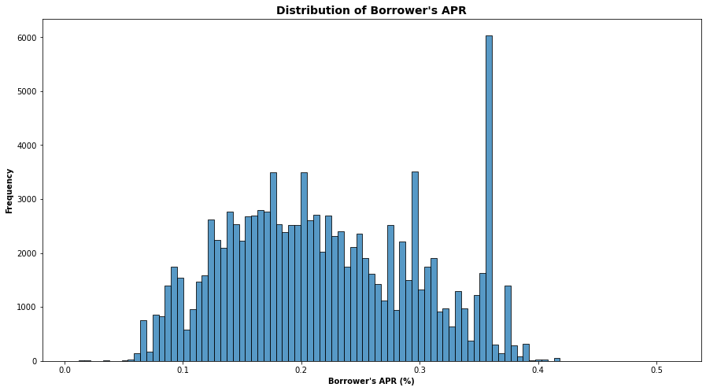

```python
# showing how the borrowerAPR is distributed
plt.figure(figsize = [15, 8])
base_color = sb.color_palette()[0]

sb.histplot(pld['BorrowerAPR'], color = base_color)
plt.xlabel("Borrower's APR (%)", fontsize = 10, weight = 'bold');
plt.ylabel('Frequency', fontsize = 10, weight = 'bold')
plt.title("Distribution of Borrower's APR", fontsize = 14, weight = 'bold');
```

The Borrower APR plot is multi-modal with the first peak before 0.1% and the highest peak around 0.3% and 0.37%

#### How is the CreditGrade distributed?

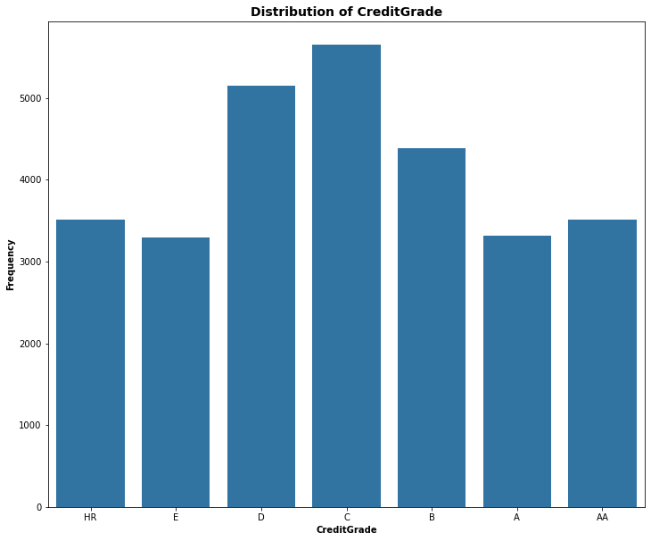

```python
#CreditGrade distribution
mycountplot(pld, 'CreditGrade', None)
```

We can see that most of the loan pre 2009 has the credit rating of C, with the D ratings following behind.

#### How is the ProsperRating (Alpha)?

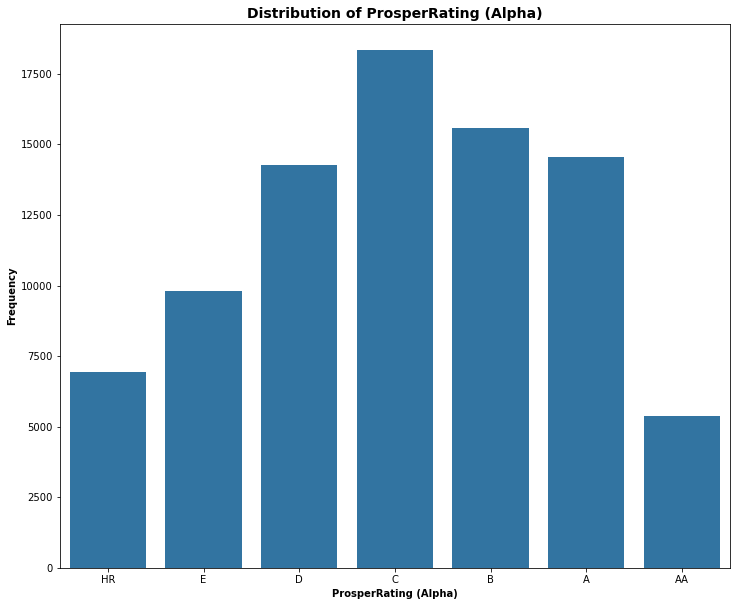

```python
#ProperRating (Alpha) distribution
mycountplot(pld, 'ProsperRating (Alpha)', None)
```

Just like the pre 2009 data, after July 2009 most loans got the C ratings only this time with the B rating coming behind.

#### How is the occupation distributed?

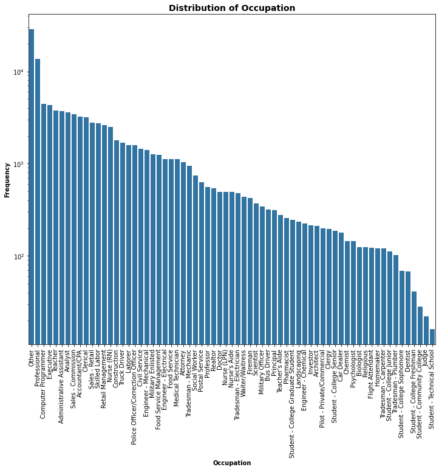

```python
# Distribution of the occupation from the data
occ_order = pld.Occupation.value_counts().index

mycountplot(pld, 'Occupation', occ_order)
plt.yscale('log')
plt.xticks(rotation = 90);
```

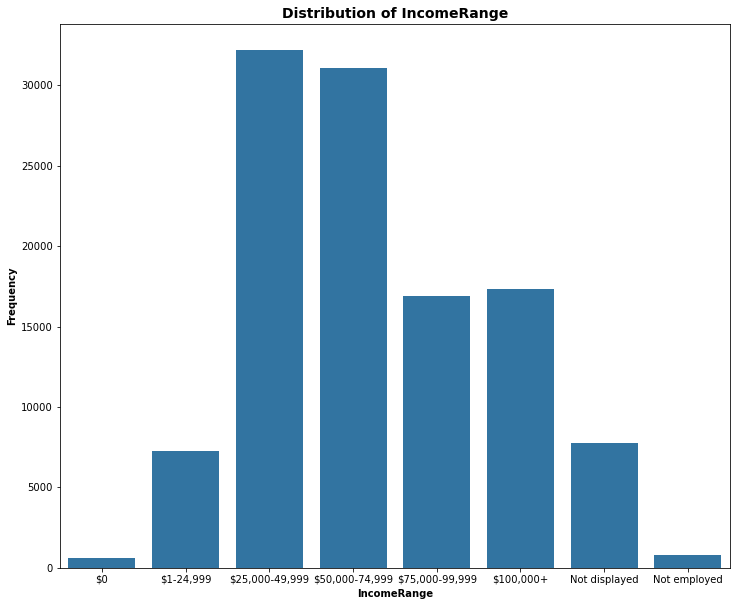

```python
# Distribution of IncomeRange
mycountplot(pld, 'IncomeRange', None)
```

Income range within \$25,000 - \\$49,999 had the highest amount of loans, followed behing closely by the \$50,000 - \\$74,999 range.

#### How is the BorrowerRate distributed?

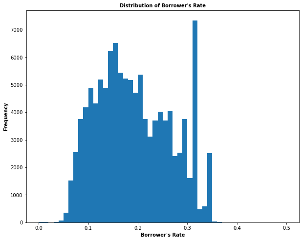

```python
#plot showing how Borrower rate is distributed
plt.figure(figsize = [10, 8])
bins = np.arange(0, pld['BorrowerRate'].max()+0.01, 0.01)
plt.hist(data = pld, x = 'BorrowerRate', color = base_color, bins = bins)

plt.xlabel("Borrower's Rate", fontsize = 10, weight = 'bold')
plt.ylabel('Frequency', fontsize = 10, weight = 'bold')
plt.title("Distribution of Borrower's Rate", fontsize = 10, weight = 'bold');
```

The Borrower's interest rate is multi-modal, with the highest peak between 0.3 and 0.33

#### How is the LoanStatus Distributed?

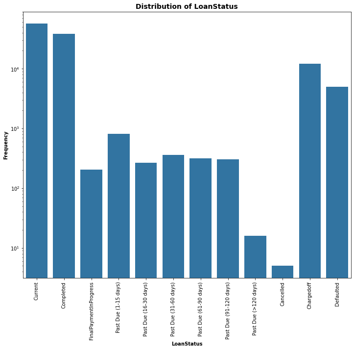

```python
#plot showing how Loan Status is distributed
mycountplot(pld, 'LoanStatus', None)
plt.yscale('log')
plt.xticks(rotation = 90);
```

From our plot we can see most of the loan are current, while the completed status folows behind. there are least loans that get cancelled.

#### How is the EmploymentStatus distributed?

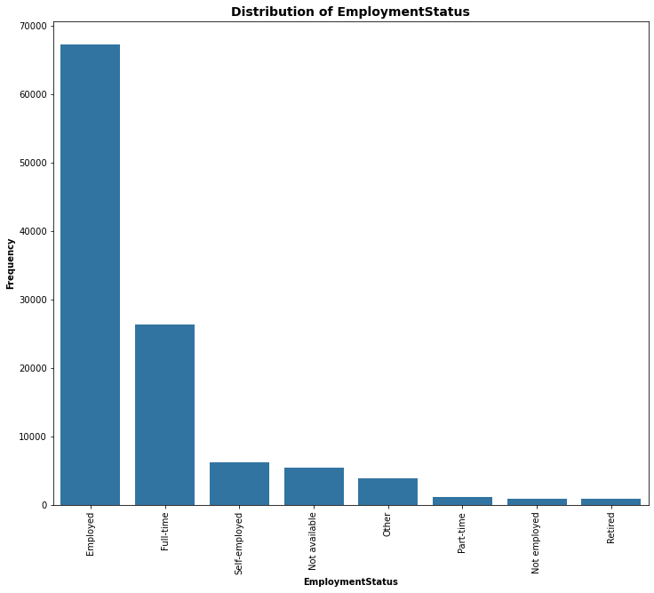

```python
#plot showing how Employment Status is distributed
mycountplot(pld, 'EmploymentStatus', None)
plt.xticks(rotation = 90);
```

Most of the loan are granted/gotten from those who are employed with the least being the Not employed and Retired status.

### Discuss the distribution(s) of your variable(s) of interest. Were there any unusual points? Did you need to perform any transformations?

> In my variable of interest (Borrower's APR), there were no unusual points nor transformations performed, the data appeared multi-modal with several peaks, first being around 0.1% and the largest peak around 0.3% and 0.37%.

## Bivariate Exploration

#### How are the Numerical Variables of interest Correlated with each other?

```python
#I want to look at the pairwise correlations present between features in the data.
num_vars = ['BorrowerAPR', 'BorrowerRate', 'StatedMonthlyIncome', 'MonthlyLoanPayment', 'EstimatedEffectiveYield',
            'EmploymentStatusDuration', 'DebtToIncomeRatio', 'LoanOriginalAmount']
cat_vars = ['IncomeRange', 'EmploymentStatus', 'LoanStatus', 'ProsperRating (Alpha)']
```

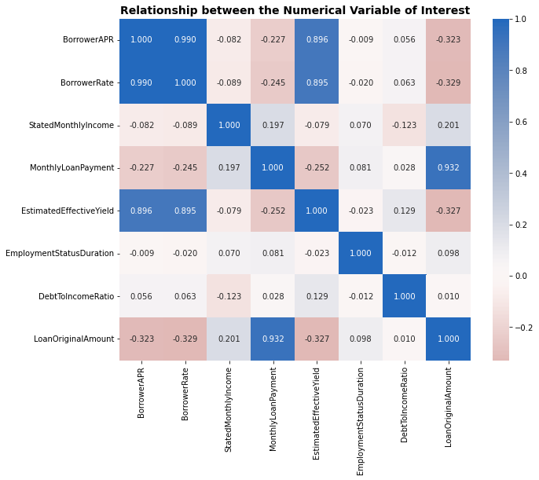

```python
# correlation plot
plt.figure(figsize = [10, 8])
sb.heatmap(pld[num_vars].corr(), annot = True, fmt = '.3f',
           cmap = 'vlag_r', center = 0)
plt.title("Relationship between the Numerical Variable of Interest", fontsize = 14, weight = 'bold')
plt.show()
```

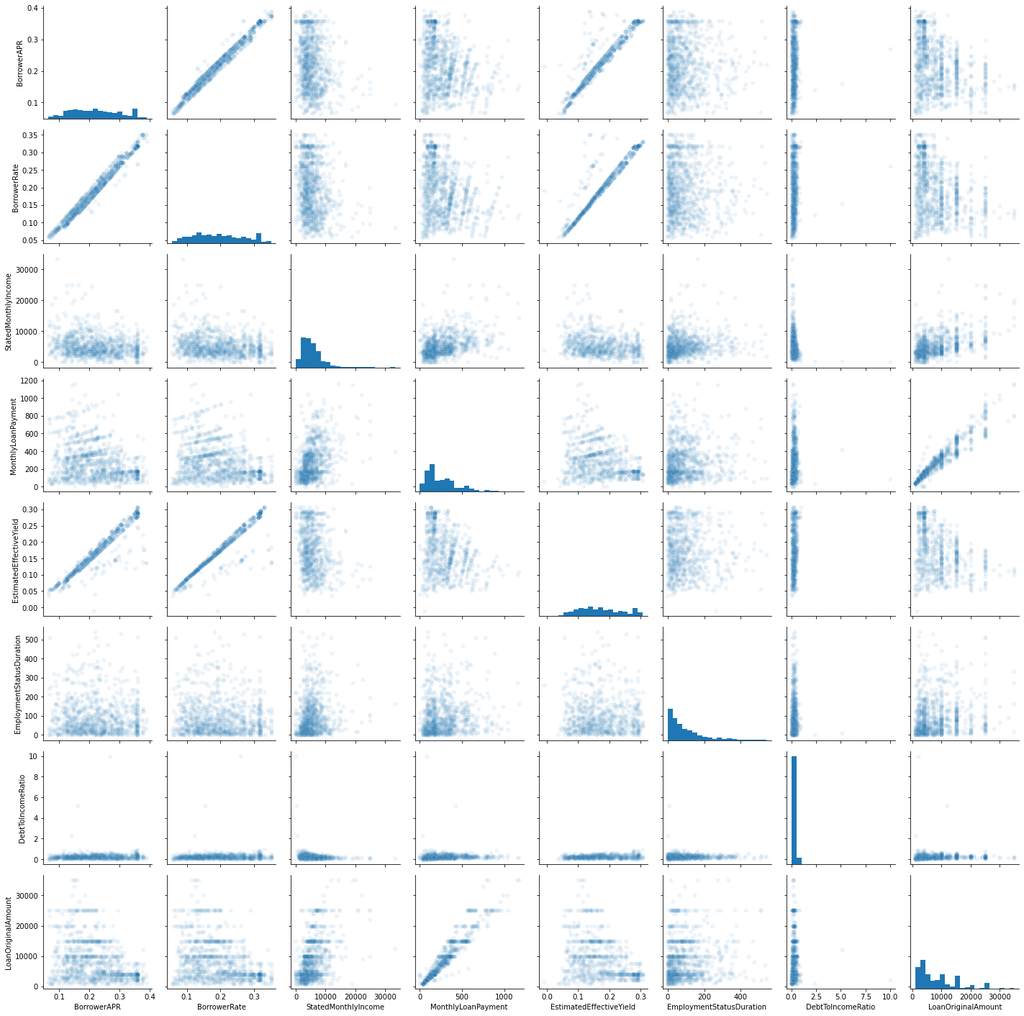

```python
# plot matrix: sample 1000 Loan samples so that plots are clearer and they render faster
samples = np.random.choice(pld.shape[0], 1000, replace = False)
pld_samp = pld.loc[samples,:]

g = sb.PairGrid(data = pld_samp, vars = num_vars)
g = g.map_diag(plt.hist, bins = 20);
g.map_offdiag(sb.scatterplot, x_jitter= True, alpha = 0.08);
```

We can see a high positive correlation between our variable of interest (BorrowerAPR) with the BorrowerRate and the EstimatedEffectiveYield, another obeservation is the positive correlation between the LoanOriginalAmount and the MonthlyLoanPayment.

#### What is the Variable of interest (BorrowerAPR), MonthlyLoanPayment, StatedMonthlyIncome relationship with other categorical variables?

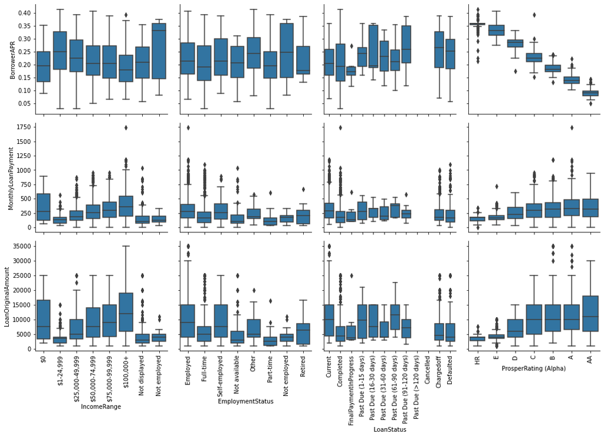

```python
# plot matrix of numeric features against categorical features.

samples = np.random.choice(pld.shape[0], 3000, replace = False)
pld_samp = pld.loc[samples,:]

def boxgrid(x, y, **kwargs):
    """ Quick hack for creating box plots with seaborn's PairGrid. """
    default_color = sb.color_palette()[0]
    sb.boxplot(x, y, color = default_color)
    plt.xticks(rotation = 90)

plt.figure(figsize = [30, 30]);
g = sb.PairGrid(data = pld_samp, y_vars = ['BorrowerAPR', 'MonthlyLoanPayment', 'LoanOriginalAmount'], x_vars = cat_vars,
                height = 3, aspect = 1.2)
g.map(boxgrid)
plt.show();
```

#### What are the relationship between the categorical variables of interest?

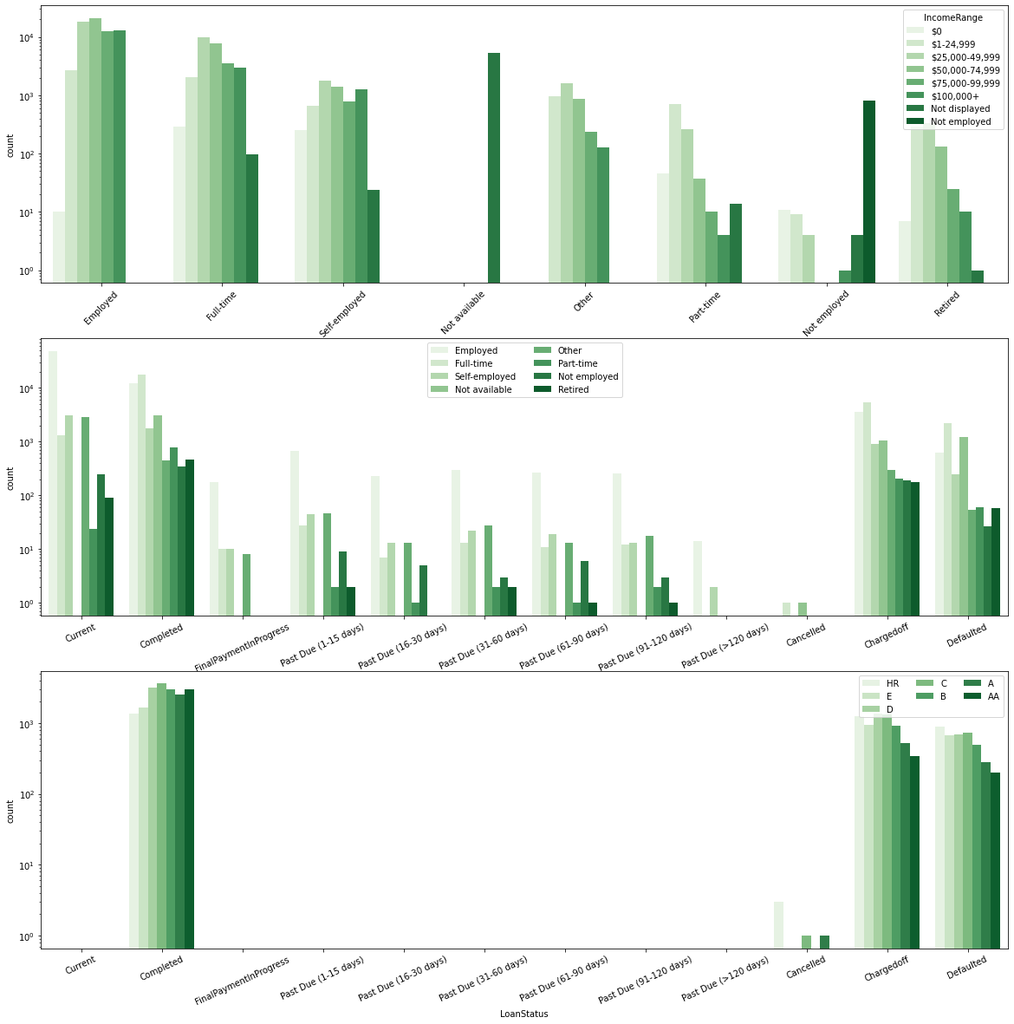

```python
plt.figure(figsize = [20, 20])

# subplot 1: EmploymentStatus vs IncomeRange
plt.subplot(3, 1, 1)
sb.countplot(data = pld, x = 'EmploymentStatus', hue = 'IncomeRange', palette = 'Greens')
plt.xticks(rotation = 45)
plt.yscale('log')

# subplot 2: LoanStatus vs ProsperRating (Alpha)
ax = plt.subplot(3, 1, 2)
sb.countplot(data = pld, x = 'LoanStatus', hue = 'EmploymentStatus', palette = 'Greens')
ax.legend(ncol = 2) # re-arrange legend to reduce overlapping
plt.xticks(rotation = 25)
plt.yscale('log')

# subplot 3: LoanStatus  vs CreditGrade,
ax = plt.subplot(3, 1, 3)
sb.countplot(data = pld, x = 'LoanStatus', hue = 'CreditGrade', palette = 'Greens')
ax.legend(loc = 1, ncol = 3) # re-arrange legend to remove overlapping
plt.xticks(rotation = 25)
plt.yscale('log')

plt.show()
```

The employed status as expected makes more income, most of the loans were taken by the employed status, data shows most of the defaulted loans were made by full time workers, while also being the most with completed status(loan repayment)

Another interesting insight is that loans with C-grade tend to pay off their loans, while HR grades tend to default.

### Talk about some of the relationships you observed in this part of the investigation. How did the feature(s) of interest vary with other features in the dataset?

> I deduced that the Borrower APR was negatively correlated with the Prosper Rating (Alpha), the higher the rating the lower the borrower's apr

## Multivariate Exploration

#### What's the relationship between the EmploymentStatus, BorrowerAPR and MonthlyLoanPayment?

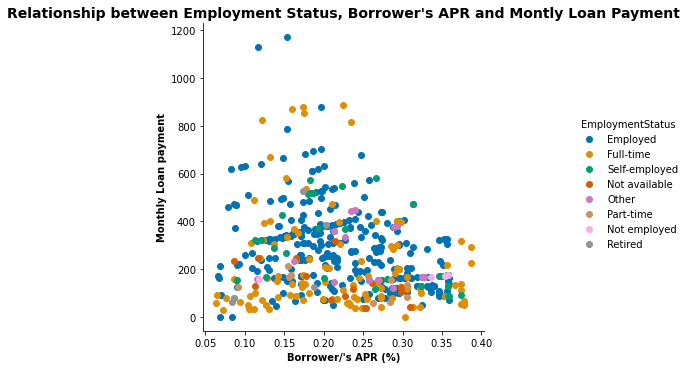

```python
#Lets start by looking at the relationship between ProsperRating (Alpha) with the BorrowerAPR and ProsperScore
samples = np.random.choice(pld.shape[0], 500, replace = False)
pld_samp = pld.loc[samples,:]

g = sb.FacetGrid(data = pld_samp, hue = 'EmploymentStatus', size = 5,
                 palette = 'colorblind')
g.map(plt.scatter, 'BorrowerAPR', 'MonthlyLoanPayment')

plt.xlabel("Borrower/'s APR (%)", fontsize = 10, weight = 'bold')
plt.ylabel("Monthly Loan payment", fontsize = 10, weight = 'bold')
plt.title("Relationship between Employment Status, Borrower's APR and Montly Loan Payment", fontsize = 14, weight = 'bold')
g.add_legend();
```

Our plot shows the employed or Full time Employment status makes higher monthly loan payment compared to other Employment status.

#### What's the relationship between the ProsperRating (Alpha), BorrowerAPR and IncomeRange?

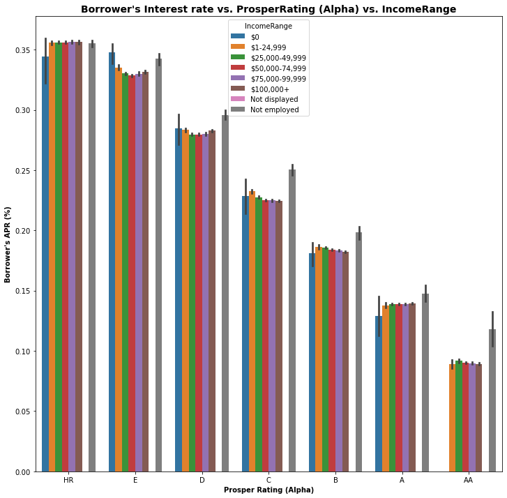

```python
#plot showing the relationship between Proper Rating (Alpha), Borrower APR and Income Range
plt.figure(figsize = [12, 12]);
sb.barplot(data = pld, x = 'ProsperRating (Alpha)', y = 'BorrowerAPR', hue = 'IncomeRange')
plt.ylabel("Borrower's APR (%)", fontsize = 10, weight = 'bold')
plt.xlabel("Prosper Rating (Alpha)", fontsize = 10, weight = 'bold')
plt.title('Borrower\'s Interest rate vs. ProsperRating (Alpha) vs. IncomeRange', fontsize = 14, weight = 'bold');
```

This shows the HR rating has a slightly higher amount of BorrowerAPR, AA rating has the least amount, the plot also show a negative correlation, the higher the ratings, the lower the BorrowerAPR.

### Talk about some of the relationships you observed in this part of the investigation. Were there features that strengthened each other in terms of looking at your feature(s) of interest?

> The AA rated loans tend to have lower annual interest rate compared to other ratings

## Conclusions

> In conclusion, The annual interest rate reduces with a higher prosper rating and also increases with the unemployed who also makes less monthly income.